# EP06

Grupo 7

2025-11-21

```r
library(emmeans)
library(ez)
library(ggpubr)
library(stringr)
library(tidyr)
```

Un equipo de investigadores del área de interacción humano-información está estudiando si el área temática y el nivel de dificultad del problema de información influyen en el tiempo (en segundos) que toma un usuario en formular una consulta de búsqueda para resolver dicho problema. Para ello, han reclutado a un grupo de participantes voluntarios, asignados aleatoriamente a distintos grupos. Cada participante debe resolver tres problemas de información con diferentes niveles de dificultad: baja, media y alta. A su vez, cada grupo debe resolver problemas relacionados a una temática diferente. Los datos recolectados contemplan las siguientes variables:

| Variable | Descripción |
| --- | --- |
| id | Identificador único de cada participante. |
| area | Área temática de los problemas que el participante debe responder. Variable categórica con los niveles Arquitectura, Biología, Computación, Economía, Física, Leyes, Literatura, Matemáticas, Música, Pe… |
| dificultad | Nivel de dificultad del problema resuelto. Variable categórica con los niveles Baja, Media y Alta. |
| tiempo | Tiempo, en segundos, que toma al participante formular la consulta. |

### Pregunta:

En este momento, los investigadores buscan determinar si existen diferencias en el tiempo que tardan los usuarios en formular consultas para problemas con diferente nivel de dificultad en el área de literatura.

Para resolver este problema se tiene que realizar la prueba de ANOVA de una via para pruebas correlacionadas con las siguientes hipotesis a constrastar:

### Hipotesis:

Ho: No existen diferencias en el tiempo que tardan los mismos usuarios en formular consultas entre los tres niveles de dificultad (Baja, Media, Alta).

H0: μ_Baja = μ_Media = μ_Alta

Ha: Existen diferencias en el tiempo según el nivel de dificultad.

Ha: μ_Baja != μ_Media != μ_Alta

### Condiciones:

Para realizar el procedimiento ANOVA es necesario verificar las siguientes condiciones:

1. La escala de la variable dependiente debe ser de intervalos iguales.

Para este punto sabemos que la variable dependiente (tiempo) está medida en segundos, por lo que cumple con esta condición.

2. Las observaciones deben ser independientes al interior de cada muestra.

Segun el enunciado los participantes fueron asignados aleatoriamente a distintos grupos, por lo que se puede asumir que las observaciones son independientes.

3. Se debe suponer razonablemente que la población de origen sigue una distribución normal.

Para verificar esta condición se pueden utilizar gráficos Q-Q para cada nivel de dificultad. Si los puntos en los gráficos Q-Q se alinean aproximadamente a lo largo de la línea diagonal, se puede asumir que la distribución es normal.

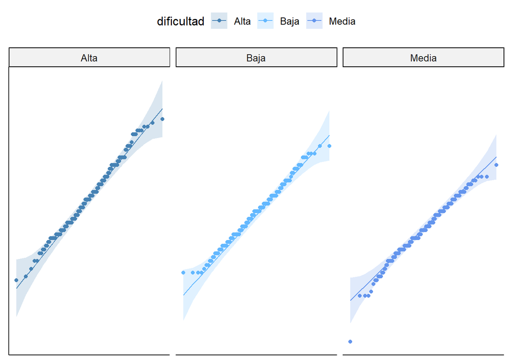

```r
library(dplyr)
datos<- read.csv("EP06 Datos.csv")

datos_licenciatura <- datos %>% filter(area=="Literatura")


# Verificar normalidad por medio de gráficos Q-Q
g1 <- ggqqplot(datos_licenciatura, x = "tiempo", y = "dificultad",
               color = "dificultad", alpha = 0.7,
               palette = c("steelblue", "steelblue1", "cornflowerblue", "steelblue4"))
g1 <- g1 + facet_wrap(~ dificultad)
g1 <- g1 + rremove("x.ticks") + rremove("x.text")
g1 <- g1 + rremove("y.ticks") + rremove("y.text")
g1 <- g1 + rremove("axis.title")
print(g1)
```

4. Se evalúa la condición de esfericidad, que implica que las varianzas (o desviaciones estándar) de las diferencias entre todos los pares de niveles dentro del factor de medidas repetidas son iguales.

Para esto realizaremos las pruebas de ANOVA para muestras correlacionadas utilizando aov() y ezANOVA(), gracias a que ezANOVA incluye la evaluación de la esfericidad mediante el test de Mauchly podremos verificar este punto.

```r
# Realizar y mostrar el procedimiento ANOVA para muestras repetidas con aov()
prueba_aov <- aov(tiempo ~ dificultad + Error(id/dificultad), data = datos_licenciatura)
print(summary(prueba_aov))
```

```
##
## Error: id
##           Df Sum Sq Mean Sq F value Pr(>F)
## Residuals  1  37.99   37.99
##
## Error: id:dificultad
##            Df Sum Sq Mean Sq
## dificultad  2   5536    2768
##
## Error: Within
##             Df Sum Sq Mean Sq F value   Pr(>F)
## dificultad   2   2046  1022.9   18.36 1.84e-08 ***
## Residuals  594  33102    55.7
## ---
## Signif. codes:  0 '***' 0.001 '**' 0.01 '*' 0.05 '.' 0.1 ' ' 1
```

```r
# Realizar y mostrar el procedimiento ANOVA para muestras repetidas con ezANOVA()
prueba_ez <- ezANOVA(data = datos_licenciatura, dv = tiempo, wid = id, within = dificultad)
print(prueba_ez)
```

```
## $ANOVA
##       Effect DFn DFd        F            p p<.05       ges
## 2 dificultad   2 398 68.24036 3.298034e-26     * 0.1858689
##
## $`Mauchly's Test for Sphericity`
##       Effect         W          p p<.05
## 2 dificultad 0.9736834 0.07134443
##
## $`Sphericity Corrections`
##       Effect       GGe        p[GG] p[GG]<.05       HFe        p[HF] p[HF]<.05
## 2 dificultad 0.9743582 1.322327e-25         * 0.9838639 7.902384e-26         *
```

Gracias a EzANOVA podemos verificar la 4ta condicion, puesto que el valor p del test de Mauchly es mayor a 0.05, por lo que no se rechaza la hipotesis nula y se cumple la condicion de esfericidad.

### Analisis del grafico:

Para complementar el analisis realizaremos una visualizacion grafica usando ezPlot:

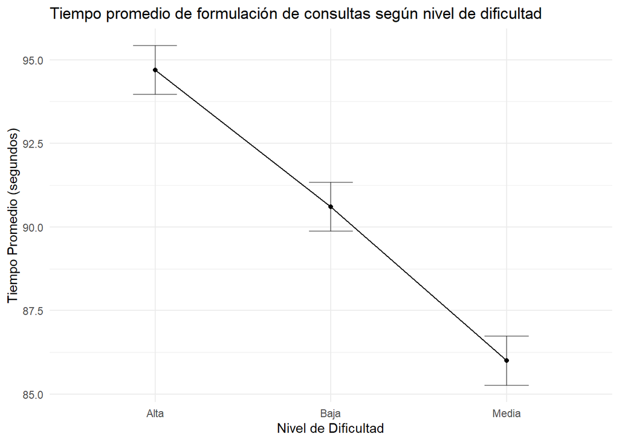

```r
ezPlot(data = datos_licenciatura,
       dv = tiempo,
       wid = id,
       within = dificultad,
       x = dificultad) +
  labs(title = "Tiempo promedio de formulación de consultas según nivel de dificultad",
       x = "Nivel de Dificultad",
       y = "Tiempo Promedio (segundos)") +
  theme_minimal()
```

### Procedimiento POST-HOC:

Gracias a este grafico podemos apoyar mas el hecho de que hay diferencias, ahora ya que nuestro intento de ANOVA resulto efectivo realizaremos una prueba post-hoc para identificar entre que niveles de dificultad existen diferencias significativas.

```r
# Realizar prueba post-hoc  con pairwise.t.test
post_hoc <- pairwise.t.test(datos_licenciatura$tiempo, datos_licenciatura$dificultad,
                            paired = TRUE,
                            p.adj = "holm", conf.level = 0.95)
print(post_hoc)
```

```
##
##  Pairwise comparisons using paired t tests
##
## data:  datos_licenciatura$tiempo and datos_licenciatura$dificultad
##
##       Alta    Baja
## Baja  1.6e-07 -
## Media < 2e-16 4.2e-10
##
## P value adjustment method: holm
```

### Interpretacion de los resultados post-hoc:

1. Comparacion entre Baja y Alta: el valor p es 1.6e-07, que es menor a 0.05, por lo que se concluye que hay una diferencia significativa en el tiempo de formulacion de consultas entre problemas de baja y alta dificultad.
2. Comparacion entre Media y Alta: el valor p es 2e-16, que es menor a 0.05, por lo que se concluye que hay una diferencia significativa en el tiempo de formulacion de consultas entre problemas de media y alta dificultad.
3. Comparacion entre Media y Baja: el valor p es 4.2e-10, que es menor a 0.05, por lo que se concluye que hay una diferencia significativa en el tiempo de formulacion de consultas entre problemas de media y baja dificultad.

Por lo tanto podemos concluir que existen diferencias significativas en el tiempo que tardan los usuarios en formular consultas para problemas con diferente nivel de dificultad en el area de literatura, especificamente entre todos los niveles de dificultad (baja, media y alta).